# Project : Investigate a Pima Indians Diabetes Dataset

- Introduction
- Data Wrangling
- Exploratory Data Analysis
- Prediction analysis
- Conclusions
- Deep Learning

## Introduction

> Diabetes is one of the deadliest diseases in the world. It is not only a disease but also creator of different kinds of diseases like heart attack, blindness etc. The normal identifying process is that patients need to visit a diagnostic center, consult their doctor, and sit tight for a day or more to get their reports. So, the objective of this project is to identify whether the patient has diabetes or not based on diagnostic measurements.. Several constraints were placed on the selection of these instances from a larger database. In particular, all patients here are females at least 21 years old of Pima Indian heritage.

> The datasets consists of several medical predictor variables and one target variable, Outcome. Predictor variables includes the number of pregnancies the patient has had, their BMI, insulin level, age, and so on.

> About Dataset:

> > Pregnancies: No. of times pregnant

> > Glucose: Plasma Glucose Concentration (mg/dl)

> > Blood Pressure: Diastolic Blood Pressure(mmHg)

> > Skin Thickness:A value used to estimate body fat. Normal Triceps SkinFold Thickness in women is 23mm. Higher thickness leads to obesity and chances of diabetes increases.

> > Insulin: 2-Hour Serum Insulin (mu U/ml)

> > BMI: Body Mass Index (weight in kg/ height in m2)

> > Diabetes Pedigree Function: It provides information about diabetes history in relatives and genetic relationship of those relatives with patients. Higher Pedigree Function means patient is more likely to have diabetes.

> > Age:Age (years)

> > Outcome: Class Variable (0 or 1) where ‘0’ denotes patient is not having diabetes and ‘1’ denotes patient having diabetes.

```python
from google.colab import drive
drive.mount('/content/drive')
```

```python
import numpy as np
import pandas as pd
import matplotlib.pyplot as plt
import seaborn as sns
%matplotlib inline
sns.set_style("whitegrid")
```

## Data Wrangling

> **Tip**: In this section of the report, you will load in the data, check for cleanliness, and then trim and clean your dataset for analysis. Make sure that you document your steps carefully and justify your cleaning decisions.

### General Properties

```python
data=pd.read_csv('/content/drive/MyDrive/Colab Notebooks/diabetes.csv')
```

```python
data.head()
```

|  | Pregnancies | Glucose | BloodPressure | SkinThickness | Insulin | BMI | DiabetesPedigreeFunction | Age | Outcome |
| --- | --- | --- | --- | --- | --- | --- | --- | --- | --- |
| 0 | 6 | 148 | 72 | 35 | 0 | 33.6 | 0.627 | 50 | 1 |
| 1 | 1 | 85 | 66 | 29 | 0 | 26.6 | 0.351 | 31 | 0 |
| 2 | 8 | 183 | 64 | 0 | 0 | 23.3 | 0.672 | 32 | 1 |
| 3 | 1 | 89 | 66 | 23 | 94 | 28.1 | 0.167 | 21 | 0 |
| 4 | 0 | 137 | 40 | 35 | 168 | 43.1 | 2.288 | 33 | 1 |

```python
data.tail()
```

|  | Pregnancies | Glucose | BloodPressure | SkinThickness | Insulin | BMI | DiabetesPedigreeFunction | Age | Outcome |
| --- | --- | --- | --- | --- | --- | --- | --- | --- | --- |
| 763 | 10 | 101 | 76 | 48 | 180 | 32.9 | 0.171 | 63 | 0 |
| 764 | 2 | 122 | 70 | 27 | 0 | 36.8 | 0.340 | 27 | 0 |
| 765 | 5 | 121 | 72 | 23 | 112 | 26.2 | 0.245 | 30 | 0 |
| 766 | 1 | 126 | 60 | 0 | 0 | 30.1 | 0.349 | 47 | 1 |
| 767 | 1 | 93 | 70 | 31 | 0 | 30.4 | 0.315 | 23 | 0 |

```python
data.info()
```

```
<class 'pandas.core.frame.DataFrame'>
RangeIndex: 768 entries, 0 to 767
Data columns (total 9 columns):
 #   Column                    Non-Null Count  Dtype
---  ------                    --------------  -----
 0   Pregnancies               768 non-null    int64
 1   Glucose                   768 non-null    int64
 2   BloodPressure             768 non-null    int64
 3   SkinThickness             768 non-null    int64
 4   Insulin                   768 non-null    int64
 5   BMI                       768 non-null    float64
 6   DiabetesPedigreeFunction  768 non-null    float64
 7   Age                       768 non-null    int64
 8   Outcome                   768 non-null    int64
dtypes: float64(2), int64(7)
memory usage: 54.1 KB
```

```python
data.isna().any()
```

```
Pregnancies                 False
Glucose                     False
BloodPressure               False
SkinThickness               False
Insulin                     False
BMI                         False
DiabetesPedigreeFunction    False
Age                         False
Outcome                     False
dtype: bool
```

```python
data.isna().sum()
```

```
Pregnancies                 0
Glucose                     0
BloodPressure               0
SkinThickness               0
Insulin                     0
BMI                         0
DiabetesPedigreeFunction    0
Age                         0
Outcome                     0
dtype: int64
```

```python
data.describe()
```

|  | Pregnancies | Glucose | BloodPressure | SkinThickness | Insulin | BMI | DiabetesPedigreeFunction | Age | Outcome |
| --- | --- | --- | --- | --- | --- | --- | --- | --- | --- |
| count | 768.000000 | 768.000000 | 768.000000 | 768.000000 | 768.000000 | 768.000000 | 768.000000 | 768.000000 | 768.000000 |
| mean | 3.845052 | 120.894531 | 69.105469 | 20.536458 | 79.799479 | 31.992578 | 0.471876 | 33.240885 | 0.348958 |
| std | 3.369578 | 31.972618 | 19.355807 | 15.952218 | 115.244002 | 7.884160 | 0.331329 | 11.760232 | 0.476951 |
| min | 0.000000 | 0.000000 | 0.000000 | 0.000000 | 0.000000 | 0.000000 | 0.078000 | 21.000000 | 0.000000 |
| 25% | 1.000000 | 99.000000 | 62.000000 | 0.000000 | 0.000000 | 27.300000 | 0.243750 | 24.000000 | 0.000000 |
| 50% | 3.000000 | 117.000000 | 72.000000 | 23.000000 | 30.500000 | 32.000000 | 0.372500 | 29.000000 | 0.000000 |
| 75% | 6.000000 | 140.250000 | 80.000000 | 32.000000 | 127.250000 | 36.600000 | 0.626250 | 41.000000 | 1.000000 |
| max | 17.000000 | 199.000000 | 122.000000 | 99.000000 | 846.000000 | 67.100000 | 2.420000 | 81.000000 | 1.000000 |

*From above description we can conclude that*

- Glucose, Blood Pressure, Skin Thickness, Insulin and BMI have missing data.
- The pregnancy column indicates the number of times a woman gets pregnant, so it makes sense that it should contain the value zero.
- But BMI= kg/m2 where kg is a person's weight in kilograms and m2 is their height in metres squared so it doesn't make sense for it to have a value of zero.
- The 0s in these column should be replaces with median, since the median is leaset affected by outliers.

## Data Cleaning

```python
# replacing the 0s with NaN
data['Glucose']= data['Glucose'].replace(0, np.nan)
data['BloodPressure']= data['BloodPressure'].replace(0, np.nan)
data['SkinThickness']= data['SkinThickness'].replace(0, np.nan)
data['Insulin']= data['Insulin'].replace(0, np.nan)
data['BMI']= data['BMI'].replace(0, np.nan)
```

```python
data.head()
```

|  | Pregnancies | Glucose | BloodPressure | SkinThickness | Insulin | BMI | DiabetesPedigreeFunction | Age | Outcome |
| --- | --- | --- | --- | --- | --- | --- | --- | --- | --- |
| 0 | 6 | 148.0 | 72.0 | 35.0 | NaN | 33.6 | 0.627 | 50 | 1 |
| 1 | 1 | 85.0 | 66.0 | 29.0 | NaN | 26.6 | 0.351 | 31 | 0 |
| 2 | 8 | 183.0 | 64.0 | NaN | NaN | 23.3 | 0.672 | 32 | 1 |
| 3 | 1 | 89.0 | 66.0 | 23.0 | 94.0 | 28.1 | 0.167 | 21 | 0 |
| 4 | 0 | 137.0 | 40.0 | 35.0 | 168.0 | 43.1 | 2.288 | 33 | 1 |

```python
data.describe()
```

|  | Pregnancies | Glucose | BloodPressure | SkinThickness | Insulin | BMI | DiabetesPedigreeFunction | Age | Outcome |
| --- | --- | --- | --- | --- | --- | --- | --- | --- | --- |
| count | 768.000000 | 763.000000 | 733.000000 | 541.000000 | 394.000000 | 757.000000 | 768.000000 | 768.000000 | 768.000000 |
| mean | 3.845052 | 121.686763 | 72.405184 | 29.153420 | 155.548223 | 32.457464 | 0.471876 | 33.240885 | 0.348958 |
| std | 3.369578 | 30.535641 | 12.382158 | 10.476982 | 118.775855 | 6.924988 | 0.331329 | 11.760232 | 0.476951 |
| min | 0.000000 | 44.000000 | 24.000000 | 7.000000 | 14.000000 | 18.200000 | 0.078000 | 21.000000 | 0.000000 |
| 25% | 1.000000 | 99.000000 | 64.000000 | 22.000000 | 76.250000 | 27.500000 | 0.243750 | 24.000000 | 0.000000 |
| 50% | 3.000000 | 117.000000 | 72.000000 | 29.000000 | 125.000000 | 32.300000 | 0.372500 | 29.000000 | 0.000000 |
| 75% | 6.000000 | 141.000000 | 80.000000 | 36.000000 | 190.000000 | 36.600000 | 0.626250 | 41.000000 | 1.000000 |
| max | 17.000000 | 199.000000 | 122.000000 | 99.000000 | 846.000000 | 67.100000 | 2.420000 | 81.000000 | 1.000000 |

```python
#count of nan values in the dataset
print(data.isnull().sum())
```

```
Pregnancies                   0
Glucose                       5
BloodPressure                35
SkinThickness               227
Insulin                     374
BMI                          11
DiabetesPedigreeFunction      0
Age                           0
Outcome                       0
dtype: int64
```

- Glucose, Blood Pressure and BMI have less missing data
- Insulin, Skin Thicness and Insulin have large amount of data missing. By this we can conclude, we cannot remove this large amount of data as number of rows are only 768. So, we will replace missing daa with median value.

```python
data.median()
```

```
Pregnancies                   3.0000
Glucose                     117.0000
BloodPressure                72.0000
SkinThickness                29.0000
Insulin                     125.0000
BMI                          32.3000
DiabetesPedigreeFunction      0.3725
Age                          29.0000
Outcome                       0.0000
dtype: float64
```

```python
#fill nan values with data median
data.fillna(data.median(), inplace=True)
```

```python
data.head()
```

|  | Pregnancies | Glucose | BloodPressure | SkinThickness | Insulin | BMI | DiabetesPedigreeFunction | Age | Outcome |
| --- | --- | --- | --- | --- | --- | --- | --- | --- | --- |
| 0 | 6 | 148.0 | 72.0 | 35.0 | 125.0 | 33.6 | 0.627 | 50 | 1 |
| 1 | 1 | 85.0 | 66.0 | 29.0 | 125.0 | 26.6 | 0.351 | 31 | 0 |
| 2 | 8 | 183.0 | 64.0 | 29.0 | 125.0 | 23.3 | 0.672 | 32 | 1 |
| 3 | 1 | 89.0 | 66.0 | 23.0 | 94.0 | 28.1 | 0.167 | 21 | 0 |
| 4 | 0 | 137.0 | 40.0 | 35.0 | 168.0 | 43.1 | 2.288 | 33 | 1 |

```python
#checking if the missing values have been imputed
print(data.isnull().sum())
```

```
Pregnancies                 0
Glucose                     0
BloodPressure               0
SkinThickness               0
Insulin                     0
BMI                         0
DiabetesPedigreeFunction    0
Age                         0
Outcome                     0
dtype: int64
```

## Outlier Detection

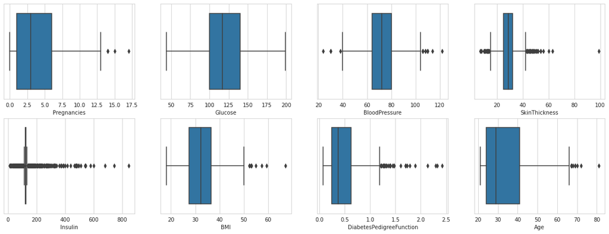

```python
#outlier detection using boxplots
plt.figure(figsize=(20, 15))
plt.subplot(4, 4, 1)
sns.boxplot(data['Pregnancies'])

plt.subplot(4, 4, 2)
sns.boxplot(data['Glucose'])

plt.subplot(4, 4, 3)
sns.boxplot(data['BloodPressure'])

plt.subplot(4, 4, 4)
sns.boxplot(data['SkinThickness'])

plt.subplot(4, 4, 5)
sns.boxplot(data['Insulin'])

plt.subplot(4, 4, 6)
sns.boxplot(data['BMI'])

plt.subplot(4, 4, 7)
sns.boxplot(data['DiabetesPedigreeFunction'])

plt.subplot(4, 4, 8)
sns.boxplot(data['Age'])
```

*There are many ways in which we can deal with Outlier and one of them is that*

- Quantile based flooring and capping

  > In this technique, the outlier is capped at a certain value above the 95th percentile value or floored at a factor below the 5th percentile value.
- Apart from Glucose all the other attributes show the presence of outliers. These lower level and upper level outliers will be replaced by 5th and 95th percentile respectively.

```python
data['Pregnancies']=data['Pregnancies'].clip(lower = data['Pregnancies'].quantile(0.05), upper = data['Pregnancies'].quantile(0.95))
data['BloodPressure']=data['BloodPressure'].clip(lower = data['BloodPressure'].quantile(0.05), upper = data['BloodPressure'].quantile(0.95))
data['SkinThickness']=data['SkinThickness'].clip(lower = data['SkinThickness'].quantile(0.05), upper = data['SkinThickness'].quantile(0.95))
data['Insulin']=data['Insulin'].clip(lower = data['Insulin'].quantile(0.05), upper = data['Insulin'].quantile(0.95))
data['BMI']=data['BMI'].clip(lower = data['BMI'].quantile(0.05), upper = data['BMI'].quantile(0.95))
data['DiabetesPedigreeFunction']=data['DiabetesPedigreeFunction'].clip(lower = data['DiabetesPedigreeFunction'].quantile(0.05), upper = data['DiabetesPedigreeFunction'].quantile(0.95))
data['Age']=data['Age'].clip(lower=data['Age'].quantile(0.05), upper=data['Age'].quantile(0.95))
```

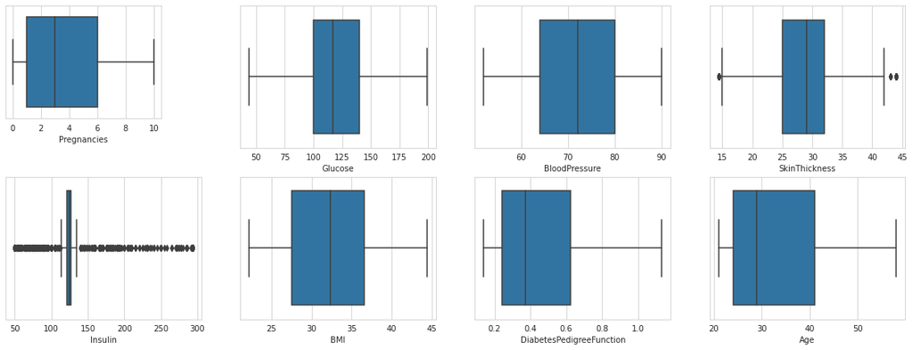

```python
#lets visulaize the boxplots after imputing the outliers
plt.figure(figsize=(20, 15))
plt.subplot(5, 5, 1)
sns.boxplot(data['Pregnancies'])

plt.subplot(4, 4, 2)
sns.boxplot(data['Glucose'])

plt.subplot(4, 4, 3)
sns.boxplot(data['BloodPressure'])

plt.subplot(4, 4, 4)
sns.boxplot(data['SkinThickness'])

plt.subplot(4, 4, 5)
sns.boxplot(data['Insulin'])

plt.subplot(4, 4, 6)
sns.boxplot(data['BMI'])

plt.subplot(4, 4, 7)
sns.boxplot(data['DiabetesPedigreeFunction'])

plt.subplot(4, 4, 8)
sns.boxplot(data['Age'])
```

```python
data['SkinThickness']=data['SkinThickness'].clip(lower = data['SkinThickness'].quantile(0.1), upper = data['SkinThickness'].quantile(0.9))
```

```python
data['Insulin']=data['Insulin'].clip(lower = data['Insulin'].quantile(0.25), upper = data['Insulin'].quantile(0.75))
```

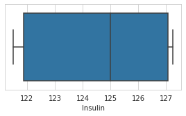

```python
plt.figure(figsize=(10,5))
plt.subplot(2,2,1)
sns.boxplot(data['Insulin'])
```

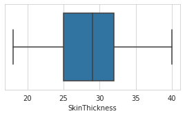

```python
plt.figure(figsize=(10,5))
plt.subplot(2,2,1)
sns.boxplot(data['SkinThickness'])
```

## Exploratory Data Analysis

### We make Some Analysis and Visualization before Questions

```python
# dataframe for people that tested negative for diabetes
df_negative = data[data['Outcome']==0]
# dataframe for people that tested positive for diabetes
df_positive = data[data['Outcome']==1]
```

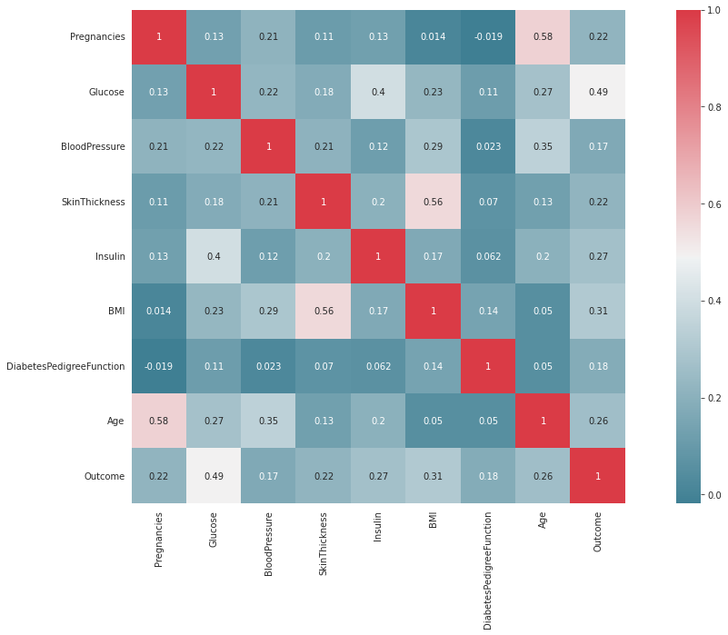

```python
# The relationship between the features and each other and between them and the target.
f, ax =plt.subplots(figsize=(20, 10))
corr = data.corr("pearson")
sns.heatmap(corr, mask=np.zeros_like(corr, dtype=np.bool), cmap=sns.diverging_palette(220, 10, as_cmap=True), square= True, ax=ax, annot=True)
```

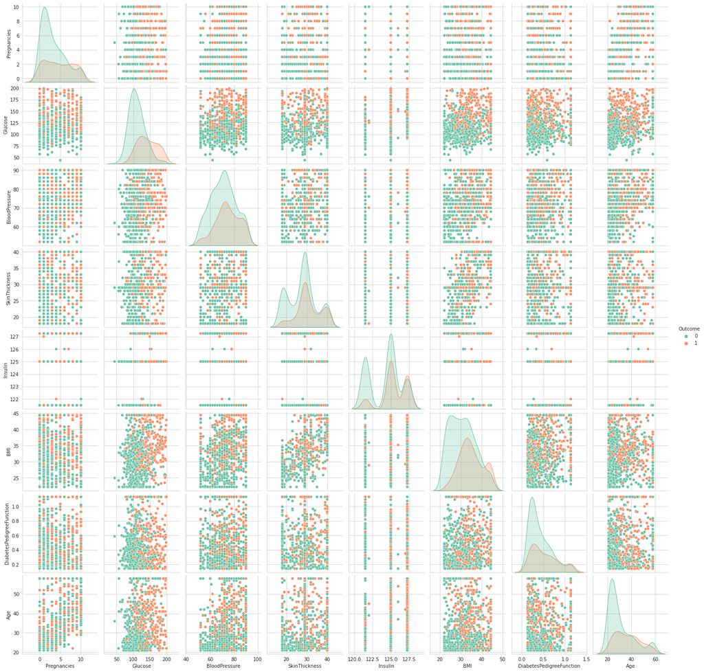

```python
# Pairplot
sns.pairplot(data,hue='Outcome',palette = "Set2")
```

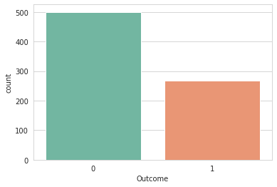

```python
#Lets start by understanding the distribution diabetic VS non-diabetic
sns.countplot(data['Outcome'],palette = "Set2")
```

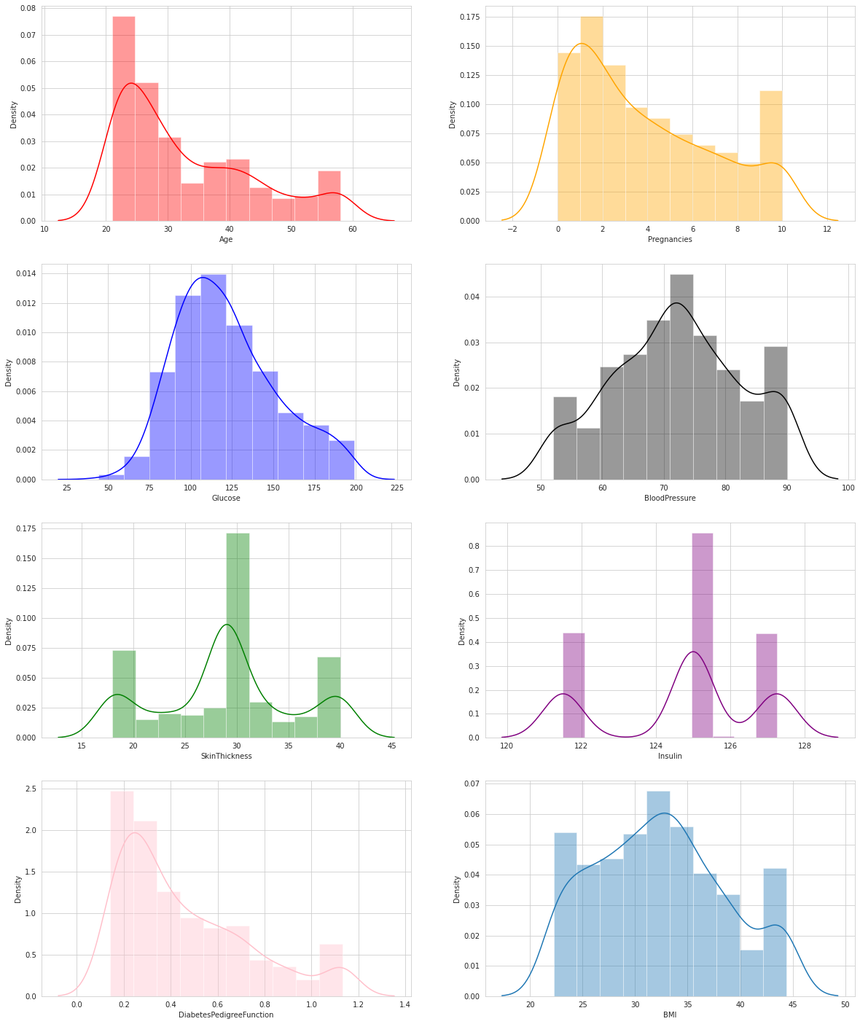

```python
# Histogram and density graphs of all variables were accessed.
fig, ax = plt.subplots(4,2, figsize=(20,25))
sns.distplot(data.Age, bins = 10, color = 'red', ax=ax[0,0])
sns.distplot(data.Pregnancies, bins = 10, color = 'orange', ax=ax[0,1])
sns.distplot(data.Glucose, bins = 10, color = 'blue', ax=ax[1,0])
sns.distplot(data.BloodPressure, bins = 10, color = 'black', ax=ax[1,1])
sns.distplot(data.SkinThickness, bins = 10, color = 'green', ax=ax[2,0])
sns.distplot(data.Insulin, bins = 10, color = 'purple', ax=ax[2,1])
sns.distplot(data.DiabetesPedigreeFunction, bins = 10, color = 'pink', ax=ax[3,0])
sns.distplot(data.BMI, bins = 10, ax=ax[3,1])
```

*Now, we will similarly plot histograms of the variables for only the people who tested negative for diabetes in the dataframe.*

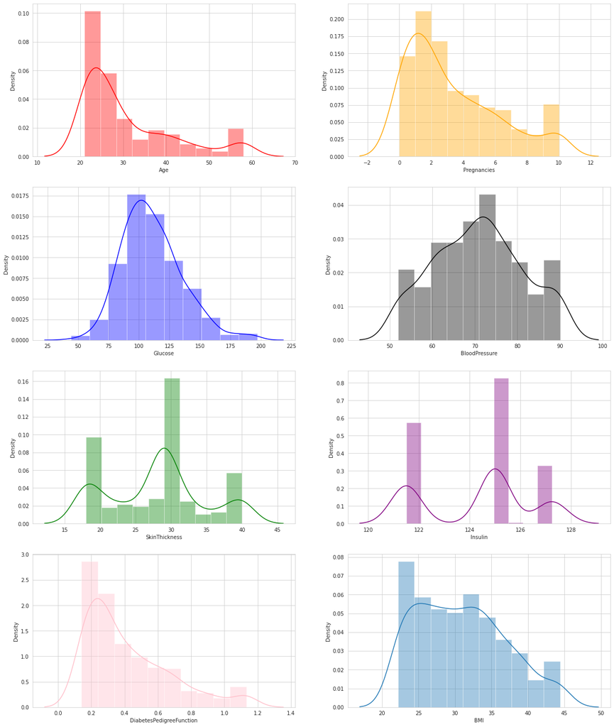

```python
# Histogram and density graphs of all variables for patients who tested negative for diabetes were accessed.
fig, ax = plt.subplots(4,2, figsize=(20,25))
sns.distplot(df_negative.Age, bins = 10, color = 'red', ax=ax[0,0])
sns.distplot(df_negative.Pregnancies, bins = 10, color = 'orange', ax=ax[0,1])
sns.distplot(df_negative.Glucose, bins = 10, color = 'blue', ax=ax[1,0])
sns.distplot(df_negative.BloodPressure, bins = 10, color = 'black', ax=ax[1,1])
sns.distplot(df_negative.SkinThickness, bins = 10, color = 'green', ax=ax[2,0])
sns.distplot(df_negative.Insulin, bins = 10, color = 'purple', ax=ax[2,1])
sns.distplot(df_negative.DiabetesPedigreeFunction, bins = 10, color = 'pink', ax=ax[3,0])
sns.distplot(df_negative.BMI, bins = 10, ax=ax[3,1])
```

*Finally, we will plot the histograms of variables for all the people who tested positive in the dataframe*

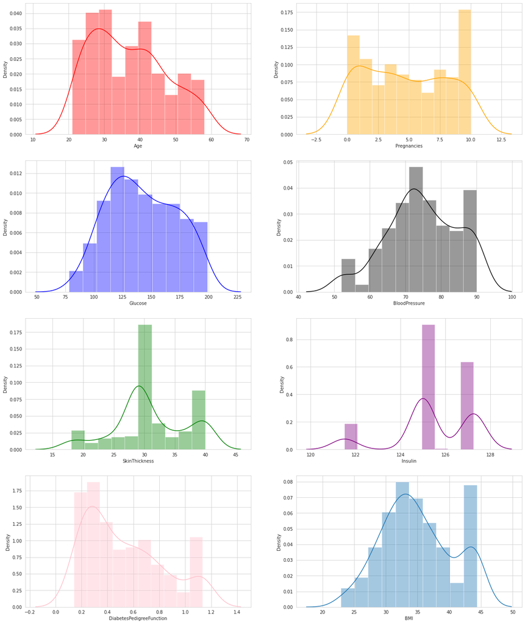

```python
# Histogram and density graphs of all variables for patients who tested positive for diabetes were accessed.
fig, ax = plt.subplots(4,2, figsize=(20,25))
sns.distplot(df_positive.Age, bins = 10, color = 'red', ax=ax[0,0])
sns.distplot(df_positive.Pregnancies, bins = 10, color = 'orange', ax=ax[0,1])
sns.distplot(df_positive.Glucose, bins = 10, color = 'blue', ax=ax[1,0])
sns.distplot(df_positive.BloodPressure, bins = 10, color = 'black', ax=ax[1,1])
sns.distplot(df_positive.SkinThickness, bins = 10, color = 'green', ax=ax[2,0])
sns.distplot(df_positive.Insulin, bins = 10, color = 'purple', ax=ax[2,1])
sns.distplot(df_positive.DiabetesPedigreeFunction, bins = 10, color = 'pink', ax=ax[3,0])
sns.distplot(df_positive.BMI, bins = 10, ax=ax[3,1])
```

### Research Question 1 : Which age group people are more prone to be diabetic?

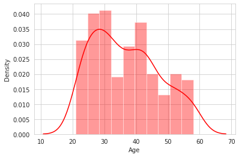

```python
sns.distplot(df_positive.Age, bins = 10, color = 'red')
```

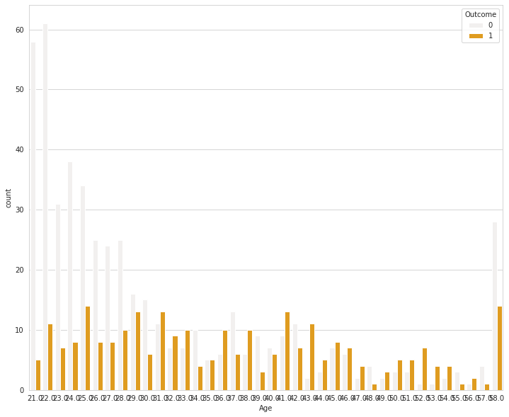

```python
plt.figure(figsize=(12,10))
sns.countplot(x='Age',hue='Outcome',data=data,color='orange')
plt.show()
```

### Research Question 2 : Are pregnant women more prone to diabetes?

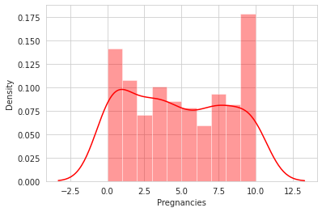

```python
sns.distplot(df_positive.Pregnancies, bins = 10, color = 'red')
```

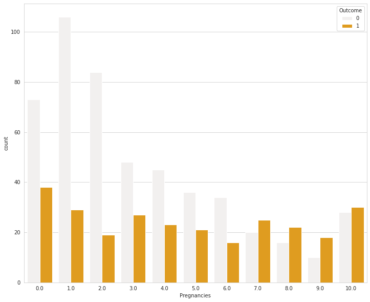

```python
plt.figure(figsize=(12,10))
sns.countplot(x='Pregnancies',hue='Outcome',data=data,color='orange')
plt.show()
```

> Pregnant women are not more likely to develop diabetes and the relationship between them is 0.22 and this shows in the graph.

### Research Question 3 : Is Glucose level a direct indication of diabetes?

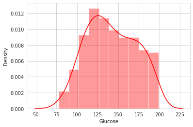

```python
sns.distplot(df_positive.Glucose, bins = 10, color = 'red')
```

> Glucose level is a direct indicator of diabetes, where the relationship between them is fifty percent.

### Research Question 4 : Does BMI affect diabetes?

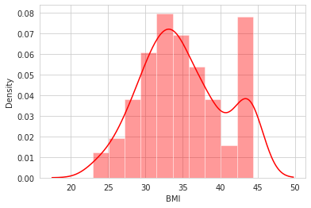

```python
sns.distplot(df_positive.BMI, bins = 10, color = 'red')
```

> High body mass index was associated with an increased prevalence of diabetes, and this appears in the relationship between them, as it reaches thirty percent.

## Build a Prediction Model

```python
from sklearn.preprocessing import StandardScaler
scaler = StandardScaler()
scaler.fit(data.drop('Outcome',axis=1))
scaled_features = scaler.transform(data.drop('Outcome',axis=1))
data_scaled = pd.DataFrame(scaled_features,columns=data.columns[:-1])
data_scaled.head()
```

|  | Pregnancies | Glucose | BloodPressure | SkinThickness | Insulin | BMI | DiabetesPedigreeFunction | Age |
| --- | --- | --- | --- | --- | --- | --- | --- | --- |
| 0 | 0.723226 | 0.866045 | -0.015221 | 0.918775 | 0.151998 | 0.205336 | 0.613891 | 1.549874 |
| 1 | -0.878382 | -1.205066 | -0.590135 | 0.010837 | 0.151998 | -0.925429 | -0.383993 | -0.177443 |
| 2 | 1.363869 | 2.016662 | -0.781773 | 0.010837 | 0.151998 | -1.458505 | 0.776589 | -0.086532 |
| 3 | -0.878382 | -1.073567 | -0.590135 | -0.897102 | -1.543319 | -0.683123 | -1.049248 | -1.086557 |
| 4 | -1.198703 | 0.504422 | -1.931599 | 0.918775 | 1.241845 | 1.739947 | 2.442802 | 0.004380 |

```python
X = data_scaled
y = data['Outcome']
```

```python
from sklearn.model_selection import train_test_split
X_train, X_test, y_train, y_test = train_test_split(X, y, test_size=0.2, random_state=42)
```

### **Logistic Regression**

```python
from sklearn.linear_model import LogisticRegression
```

```python
model = LogisticRegression()
model.fit(X_train,y_train)
```

```
LogisticRegression()
```

```python
prediction = model.predict(X_test)
```

```python
from sklearn.metrics import classification_report, confusion_matrix
```

```python
print(classification_report(y_test,prediction))
```

```
              precision    recall  f1-score   support

           0       0.81      0.81      0.81        99
           1       0.65      0.65      0.65        55

    accuracy                           0.75       154
   macro avg       0.73      0.73      0.73       154
weighted avg       0.75      0.75      0.75       154
```

### **Random Forest**

```python
from sklearn.ensemble import RandomForestClassifier
from sklearn.model_selection import KFold, GridSearchCV
```

```python
seed = 4
rf = RandomForestClassifier(random_state=seed)
kf = KFold(n_splits=5, shuffle=False)

params = {
    'n_estimators': [5,10,25,50,75,150,200],
    'max_depth': [2, 4 , 6 , 8 , 10],
}
grid_no_up = GridSearchCV(rf, param_grid=params, cv=kf, scoring='accuracy', verbose=1, n_jobs=-1)
grid_no_up.fit(X_train, y_train)

best_hyperparams = grid_no_up.best_params_
print('Best hyerparameters:\n' , best_hyperparams)

best_CV_score = grid_no_up.best_score_
print('Best CV accuracy')
print(best_CV_score)

best_model = grid_no_up.best_estimator_
```

```
Fitting 5 folds for each of 35 candidates, totalling 175 fits
Best hyerparameters:
 {'max_depth': 10, 'n_estimators': 150}
Best CV accuracy
0.7736372117819539
```

```python
rfc = RandomForestClassifier(n_estimators = 50, max_depth = 10)
rfc.fit(X_train,y_train)
pred = rfc.predict(X_test)

print(confusion_matrix(y_test,pred))
print('\n')
print(classification_report(y_test,pred))
```

```
[[80 19]
 [17 38]]


              precision    recall  f1-score   support

           0       0.82      0.81      0.82        99
           1       0.67      0.69      0.68        55

    accuracy                           0.77       154
   macro avg       0.75      0.75      0.75       154
weighted avg       0.77      0.77      0.77       154
```

### **KNeighbors**

```python
from sklearn.neighbors import KNeighborsClassifier
```

```python
error_rate = []

for i in range(1,40):

    knn = KNeighborsClassifier(n_neighbors=i)
    knn.fit(X_train,y_train)
    pred_i = knn.predict(X_test)
    error_rate.append(np.mean(pred_i != y_test))
```

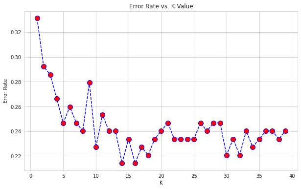

```python
plt.figure(figsize=(10,6))
plt.plot(range(1,40),error_rate,color='blue', linestyle='dashed', marker='o',
         markerfacecolor='red', markersize=10)
plt.title('Error Rate vs. K Value')
plt.xlabel('K')
plt.ylabel('Error Rate')
```

```python
knn = KNeighborsClassifier(n_neighbors=14)

knn.fit(X_train,y_train)
pred = knn.predict(X_test)

print('WITH K=14')
print('\n')
print(confusion_matrix(y_test,pred))
print('\n')
print(classification_report(y_test,pred))
```

```
WITH K=14


[[87 12]
 [21 34]]


              precision    recall  f1-score   support

           0       0.81      0.88      0.84        99
           1       0.74      0.62      0.67        55

    accuracy                           0.79       154
   macro avg       0.77      0.75      0.76       154
weighted avg       0.78      0.79      0.78       154
```

### **Decision Tree**

```python
from sklearn.tree import DecisionTreeClassifier
from sklearn.model_selection import GridSearchCV
params = {'max_leaf_nodes': list(range(2,25)), 'min_samples_split': [2, 3, 4],"criterion":["gini","entropy"],"max_depth": list(range(1,10))}
grid = GridSearchCV(DecisionTreeClassifier(),param_grid=params, cv=10, n_jobs=-1)
grid.fit(X_train, y_train)
```

```
GridSearchCV(cv=10, estimator=DecisionTreeClassifier(), n_jobs=-1,
             param_grid={'criterion': ['gini', 'entropy'],
                         'max_depth': [1, 2, 3, 4, 5, 6, 7, 8, 9],
                         'max_leaf_nodes': [2, 3, 4, 5, 6, 7, 8, 9, 10, 11, 12,
                                            13, 14, 15, 16, 17, 18, 19, 20, 21,
                                            22, 23, 24],
                         'min_samples_split': [2, 3, 4]})
```

```python
grid.best_estimator_
```

```
DecisionTreeClassifier(criterion='entropy', max_depth=6, max_leaf_nodes=10)
```

```python
grid.best_score_
```

```
0.7801427815970385
```

### SVM

```python
from sklearn.svm import SVC
model = SVC()
# defining parameter range
param_grid = {'C': [0.1, 1, 10, 100, 1000],
              'gamma': [1, 0.1, 0.01, 0.001, 0.0001],
              'kernel': ['rbf']}

grid = GridSearchCV(SVC(), param_grid, refit = True, verbose = 3)

# fitting the model for grid search
grid.fit(X_train, y_train)
```

```
Fitting 5 folds for each of 25 candidates, totalling 125 fits
[CV 1/5] END ........C=0.1, gamma=1, kernel=rbf;, score=0.659 total time=   0.0s
[CV 2/5] END ........C=0.1, gamma=1, kernel=rbf;, score=0.650 total time=   0.0s
[CV 3/5] END ........C=0.1, gamma=1, kernel=rbf;, score=0.650 total time=   0.0s
[CV 4/5] END ........C=0.1, gamma=1, kernel=rbf;, score=0.650 total time=   0.0s
[CV 5/5] END ........C=0.1, gamma=1, kernel=rbf;, score=0.656 total time=   0.0s
[CV 1/5] END ......C=0.1, gamma=0.1, kernel=rbf;, score=0.699 total time=   0.0s
[CV 2/5] END ......C=0.1, gamma=0.1, kernel=rbf;, score=0.780 total time=   0.0s
[CV 3/5] END ......C=0.1, gamma=0.1, kernel=rbf;, score=0.748 total time=   0.0s
[CV 4/5] END ......C=0.1, gamma=0.1, kernel=rbf;, score=0.748 total time=   0.0s
[CV 5/5] END ......C=0.1, gamma=0.1, kernel=rbf;, score=0.762 total time=   0.0s
[CV 1/5] END .....C=0.1, gamma=0.01, kernel=rbf;, score=0.667 total time=   0.0s
[CV 2/5] END .....C=0.1, gamma=0.01, kernel=rbf;, score=0.650 total time=   0.0s
[CV 3/5] END .....C=0.1, gamma=0.01, kernel=rbf;, score=0.650 total time=   0.0s
[CV 4/5] END .....C=0.1, gamma=0.01, kernel=rbf;, score=0.650 total time=   0.0s
[CV 5/5] END .....C=0.1, gamma=0.01, kernel=rbf;, score=0.656 total time=   0.0s
[CV 1/5] END ....C=0.1, gamma=0.001, kernel=rbf;, score=0.659 total time=   0.0s
[CV 2/5] END ....C=0.1, gamma=0.001, kernel=rbf;, score=0.650 total time=   0.0s
[CV 3/5] END ....C=0.1, gamma=0.001, kernel=rbf;, score=0.650 total time=   0.0s
[CV 4/5] END ....C=0.1, gamma=0.001, kernel=rbf;, score=0.650 total time=   0.0s
[CV 5/5] END ....C=0.1, gamma=0.001, kernel=rbf;, score=0.656 total time=   0.0s
[CV 1/5] END ...C=0.1, gamma=0.0001, kernel=rbf;, score=0.659 total time=   0.0s
[CV 2/5] END ...C=0.1, gamma=0.0001, kernel=rbf;, score=0.650 total time=   0.0s
[CV 3/5] END ...C=0.1, gamma=0.0001, kernel=rbf;, score=0.650 total time=   0.0s
[CV 4/5] END ...C=0.1, gamma=0.0001, kernel=rbf;, score=0.650 total time=   0.0s
[CV 5/5] END ...C=0.1, gamma=0.0001, kernel=rbf;, score=0.656 total time=   0.0s
[CV 1/5] END ..........C=1, gamma=1, kernel=rbf;, score=0.683 total time=   0.0s
[CV 2/5] END ..........C=1, gamma=1, kernel=rbf;, score=0.667 total time=   0.0s
[CV 3/5] END ..........C=1, gamma=1, kernel=rbf;, score=0.659 total time=   0.0s
[CV 4/5] END ..........C=1, gamma=1, kernel=rbf;, score=0.707 total time=   0.0s
[CV 5/5] END ..........C=1, gamma=1, kernel=rbf;, score=0.746 total time=   0.0s
[CV 1/5] END ........C=1, gamma=0.1, kernel=rbf;, score=0.756 total time=   0.0s
[CV 2/5] END ........C=1, gamma=0.1, kernel=rbf;, score=0.772 total time=   0.0s
[CV 3/5] END ........C=1, gamma=0.1, kernel=rbf;, score=0.724 total time=   0.0s
[CV 4/5] END ........C=1, gamma=0.1, kernel=rbf;, score=0.764 total time=   0.0s
[CV 5/5] END ........C=1, gamma=0.1, kernel=rbf;, score=0.770 total time=   0.0s
[CV 1/5] END .......C=1, gamma=0.01, kernel=rbf;, score=0.740 total time=   0.0s
[CV 2/5] END .......C=1, gamma=0.01, kernel=rbf;, score=0.797 total time=   0.0s
[CV 3/5] END .......C=1, gamma=0.01, kernel=rbf;, score=0.772 total time=   0.0s
[CV 4/5] END .......C=1, gamma=0.01, kernel=rbf;, score=0.732 total time=   0.0s
```

[output cut: 71 more lines]

```
[CV 1/5] END ....C=1000, gamma=0.01, kernel=rbf;, score=0.764 total time=   0.0s
[CV 2/5] END ....C=1000, gamma=0.01, kernel=rbf;, score=0.780 total time=   0.0s
[CV 3/5] END ....C=1000, gamma=0.01, kernel=rbf;, score=0.707 total time=   0.0s
[CV 4/5] END ....C=1000, gamma=0.01, kernel=rbf;, score=0.715 total time=   0.0s
[CV 5/5] END ....C=1000, gamma=0.01, kernel=rbf;, score=0.779 total time=   0.0s
[CV 1/5] END ...C=1000, gamma=0.001, kernel=rbf;, score=0.740 total time=   0.0s
[CV 2/5] END ...C=1000, gamma=0.001, kernel=rbf;, score=0.805 total time=   0.0s
[CV 3/5] END ...C=1000, gamma=0.001, kernel=rbf;, score=0.740 total time=   0.0s
[CV 4/5] END ...C=1000, gamma=0.001, kernel=rbf;, score=0.740 total time=   0.0s
[CV 5/5] END ...C=1000, gamma=0.001, kernel=rbf;, score=0.795 total time=   0.0s
[CV 1/5] END ..C=1000, gamma=0.0001, kernel=rbf;, score=0.732 total time=   0.0s
[CV 2/5] END ..C=1000, gamma=0.0001, kernel=rbf;, score=0.789 total time=   0.0s
[CV 3/5] END ..C=1000, gamma=0.0001, kernel=rbf;, score=0.764 total time=   0.0s
[CV 4/5] END ..C=1000, gamma=0.0001, kernel=rbf;, score=0.740 total time=   0.0s
[CV 5/5] END ..C=1000, gamma=0.0001, kernel=rbf;, score=0.787 total time=   0.0s
```

```
GridSearchCV(estimator=SVC(),
             param_grid={'C': [0.1, 1, 10, 100, 1000],
                         'gamma': [1, 0.1, 0.01, 0.001, 0.0001],
                         'kernel': ['rbf']},
             verbose=3)
```

```python
# print best parameter after tuning
print(grid.best_params_)

# print how our model looks after hyper-parameter tuning
print(grid.best_estimator_)
```

```
{'C': 100, 'gamma': 0.001, 'kernel': 'rbf'}
SVC(C=100, gamma=0.001)
```

```python
grid_predictions = grid.predict(X_test)

# print classification report
print(classification_report(y_test, grid_predictions))
```

```
              precision    recall  f1-score   support

           0       0.80      0.81      0.80        99
           1       0.65      0.64      0.64        55

    accuracy                           0.75       154
   macro avg       0.72      0.72      0.72       154
weighted avg       0.75      0.75      0.75       154
```

## Compare the performance (Confusion matrix and classification report) of different classifiers (LR, KNN, SVM, DT and RF)

- The best performance from this models : **KNeighborsClassifier** Accuracy : **79%**
- Second in terms of performance : **DecisionTree** Accuracy : **78%**
- Third in terms of performance : **RandomForestClassifier** Accuracy : **77%**
- Last in terms of performance : **SVM and LogisticRegression** Accuracy : **75%**

# Deep Learning

### Train and evaluate the model

```python
from keras.models import Sequential
from keras.layers import Dense, Dropout
```

```python
model = Sequential()
model.add(Dense(12, input_dim=8, activation='relu'))
model.add(Dense(8, activation='relu'))
model.add(Dropout(.2))
model.add(Dense(4, activation='relu'))
model.add(Dense(1, activation='sigmoid'))
model.compile(loss="mse", optimizer="adam", metrics=['accuracy'])
```

```python
model.summary()
```

```
Model: "sequential_2"
_________________________________________________________________
 Layer (type)                Output Shape              Param #
=================================================================
 dense_8 (Dense)             (None, 12)                108

 dense_9 (Dense)             (None, 8)                 104

 dropout_2 (Dropout)         (None, 8)                 0

 dense_10 (Dense)            (None, 4)                 36

 dense_11 (Dense)            (None, 1)                 5

=================================================================
Total params: 253
Trainable params: 253
Non-trainable params: 0
_________________________________________________________________
```

```python
history=model.fit(X_train, y_train, epochs = 250, batch_size=15, validation_data=(X_test, y_test))
```

```
dict_keys(['loss', 'accuracy', 'val_loss', 'val_accuracy'])
```

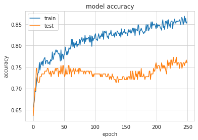

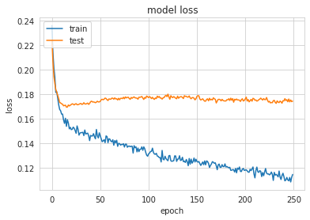

```python
# list all data in history
print(history.history.keys())
print("\n")
# summarize history for accuracy
plt.plot(history.history['accuracy'])
plt.plot(history.history['val_accuracy'])
plt.title('model accuracy')
plt.ylabel('accuracy')
plt.xlabel('epoch')
plt.legend(['train', 'test'], loc='upper left')
plt.show()
print("\n")
# summarize history for loss
plt.plot(history.history['loss'])
plt.plot(history.history['val_loss'])
plt.title('model loss')
plt.ylabel('loss')
plt.xlabel('epoch')
plt.legend(['train', 'test'], loc='upper left')
plt.show()
```